# Applied Math 10: Computing for Science and Engineering

## FINAL Assignment

**Fall 2020**

Handed out: Thursday, Dec. 3, 2020

Due: 11.59 pm; Sunday, Dec. 13, 2020

### Instructions

The rules for the Final Project are:

a) We will not offer any assistance in the form of Sections or Office Hours, this is really a "Final": it's a project rather than an exam, but it's still a final which you need to do without help from the teaching staff, and it will cover everything you have learned in the course.

b) We will leave the general `Slack` channel for the AM10 course open, until Thu. Dec. 10, 5:00pm (for one week from the time the Final Project is posted): in this `Slack` channel you can ask questions only for clarification of something that may not be clear in the Final Project, but no other types of questions.

c) You are allowed to discuss with your fellow students HOW to solve the problems (the method), but you need to hand in your INDIVIDUAL SOLUTION. We will be strict with the rule for individual solutions. Any transgressions (identical pieces of code) will cost points to all parties involved.

d) We require you to list fellow students that you worked with in arriving at a solution, so we can check the level of individuality in each solution you hand in.

e) You can use code from previous Homeworks or any other code we developed in the course (Lectures, Labs, Sections) - you don't neeed to reference this, it is part of the knowledge you acquired in this course. However, if you use code from other sources, you MUST include a reference to the source.

f) There will be no extensions in the Final Project for any reason. Please plan your time accordingly.

```python
import numpy as np
import random as rd
import matplotlib.pyplot as plt
import matplotlib.cm as cm
from mpl_toolkits.mplot3d import Axes3D
%matplotlib inline
# I discussed the definition of variance as well as a theoretical apppraoch to Question 2 with Courtney Rabb
```

## Problem 1: Escape from an energy well

### Preamble

In 1868, the Austrian physicist Ludwig Boltzmann presented his work on a very important, exponential distribution, which applies to any physical systesm: if a state of the system has energy $\epsilon _i$, the probability $p_i$ of finding this state is given by:

$$ p_i =\frac{1}{Z} e^{-\epsilon_i/k_B T}, \; \; \; Z = \sum_i e^{-\epsilon_i/k_B T}$$

where the constant $k_B$ is Boltzmann's constant and $T$ is the temperature. The expression for $p_i$ is called the "Boltzmann distribution"; it has applications in a plethora of fields, ranging from statistical mechanics, mathematics, spectroscopy, machine learning and even economics, among others. So being able to use an exponential probability distribution is very important. In this problem you will start with a uniform probability distribution to generate the exponential (Boltzmann) distribution, and then apply it to the 1D random walk problem.

### Statement of the problem

(a) In this part, you will generate exponentially distributed random numbers $x_r$, using the following transformation:

\begin{equation} x_r = -\frac{\ln{u}}{\lambda} \Rightarrow u = e^{-\lambda x_r} \end{equation}

where $x_r$ is a random number with the exponential distribution, $\lambda$ is a constant, and $u$ is a random number with uniform distribution. By comparing the above expression to the Boltzmann distribution we see that $\lambda = 1/k_B T$.

Using the above expression transform a sequence of $N=1000$ random numbers generated using the function u = `np.random.random` to an exponential distribution with $\lambda=2$ (make sure that you exclude the value u=0 because it makes the logarithm to diverge). Plot a histogram of the resulting sequence with 20 bins. Use the keyword `density=True` to normalize the counts. On the same plot also add a line representing the following equation: $y(x) = \lambda e^{-\lambda x}$.

(b) Next, we will consider random walks in one dimension (1D), but with the probability of taking a step not based on a uniform distribution, but on an exponential distribution (like the Boltzmann one). The justification is that the "energy" is proportional to the magnitude of the step, that is, it matters how big a step the walker is trying to make.

Make a 1D simulation with exponential distribution of the steps, such that the probability of taking a step is given by $$ p_i = \lambda e^{-\lambda |\Delta x_i|}$$ where $|\Delta x_i|$ is the distance between the current and new positions. To do this, you must first choose a random distance $\Delta x_i$ from the current position (this can be positive of negative), then calculate the probability $p_i$ from the expression above (don't forget the absolute value of $\Delta x_i$), and then compare this probability with a random number $r_i$ with uniform distribution: if $p_i$ is LARGER than $r_i$, then the step is accepted and the walker moves by $\Delta x_i$, but if $p_i$ is SMALLER than $r_i$ the step is rejected, and a different move (with different random $\Delta x_i$) is chosen in the next time step.

To be specific, there are several different parts to this process:

1) choose a random $\Delta x_i$ from a uniform distribution, i.e. $\alpha$*(np.random.rand()-0.5), where $\alpha$ is a real number (not necessarily equal to 1)

2) calculate $p_i$

3) draw a new random number $r_i$ of uniform distribution

4) compare $p_i$ to $r_i$, and reject or accept the move, as explained above

5) update the position of the walker, if the move is accepted; the walker stays in the same position if the move is rejected.

You should use a large number of walkers for this simulation and a large number of time steps (the same for all walkers). Consider different values of $\lambda$ and $\alpha$ (of your own choice).

Calculate the average position $\langle x \rangle$ for each time step, averaging over all the walkers, and plot it as a function of time.

Calculate the variance $\langle x^2 \rangle$ as a function of time.

(c) Compare the results of this simulation (consider $\lambda=2$ and $\alpha=1$, but also compare results with other values of $\lambda$ and $\alpha$). to the simulation that we investigated in Lecture 12 which used a uniform distribution of steps in each direction, independent of the length of the move. Specifically, compare the average and variance for the two different probability distributions.

```
PART A
```

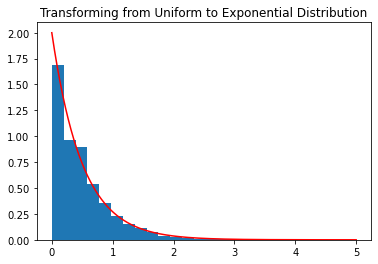

```
As you can see, the given equation (graphed in red) matches the histogram quite well!

PART B
```

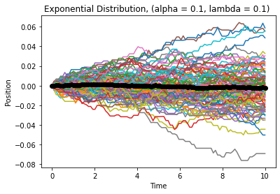

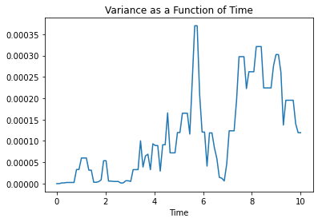

```
The position averaged over number of walks and number of walkers is  -0.0005549182686143578
The average variance is 0.00011315312961481028

PART C
```

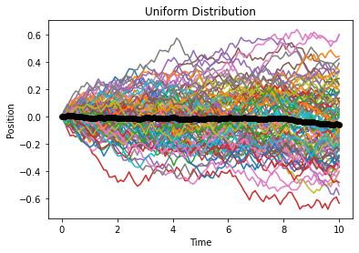

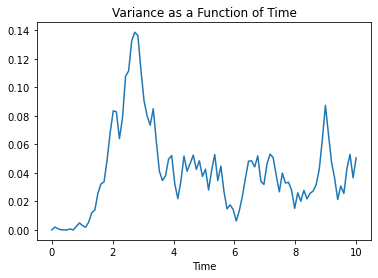

```
The position averaged over number of walks and number of walkers is  -0.017123704647647058
The average variance is 0.04123807372445923
```

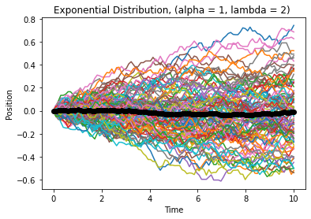

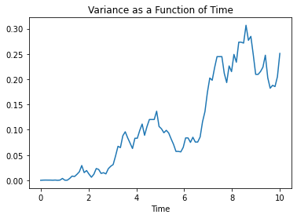

[output not shown]

```python
print('PART A')
N = 1000 # number of walkers
u = np.zeros(N) # initialize
xr = np.zeros(N) # initialize
for j in range(N):
    lam = 2 # lambda value given
    epsilon = 0.0000000001 # define a really small epsilon to avoid the singularity at 0
    u[j]=np.random.random() + epsilon # pull a random number from a uniform distribution
    xr[j]= -np.log(u[j])/lam # plug that random number into this expression
plt.hist(xr,bins = 20, density=True) # histogram with 20 bins
lam = 2 # lambda value given
epsilon = 0.0000000001 # define a really small epsilon to avoid the singularity at 0
x = np.linspace(epsilon,5,N)
y = lam*np.exp(-lam*x)
plt.plot(x,y,"r-") # plotting
plt.title("Transforming from Uniform to Exponential Distribution")
plt.show()
print("As you can see, the given equation (graphed in red) matches the histogram quite well!")
print()
print('PART B')

tmax = 10
dt = 0.1
num_times=int(tmax/dt)

time = np.linspace(0,tmax,num_times) # create time linspace
r=np.zeros(num_times) # intialize everything I need
dxi=np.zeros(num_times)
pi=np.zeros(num_times)
ri=np.zeros(num_times)
v=np.zeros(num_times)
Nwalkers = 100 # number of walkers
rav=np.zeros(num_times)

for nw in range(Nwalkers): # for loop for each walker

    for n in range(1,num_times): # for loop for each walk
        alpha = 0.1 # we can choose this
        lam = 0.1 # we can choose this
        dxi[n] = alpha*(np.random.rand()-0.5)
        pi[n] = lam * np.exp(-lam*np.abs(dxi[n]))
        ri[n] = np.random.randn()
        if pi[n] > ri[n]: # move is accepted, position changes
            r[n]=r[n-1]+ dxi[n]*dt
            rav[n]=rav[n]+r[n]
            v[n]=np.mean(r[n]**2) # calculate var like we did in week 12
        else: # move is rejected, position stays the same
            r[n]=r[n-1] # no change
            rav[n]=rav[n]+r[n]
            v[n]=np.mean(r[n]**2) # calculate var like we did in week 12
    plt.plot(time,r) # plot each walkers path

x=rav/Nwalkers # array for position at each step averaged over the walkers
mean_of_exp = np.mean(x) # scalar, average of an average
plt.plot(time,x,'ko-',linewidth='1') # plot average position as a thick black line
plt.title("Exponential Distribution, (alpha = 0.1, lambda = 0.1) ")
plt.xlabel("Time")
plt.ylabel("Position")
plt.show()
plt.plot(time,v)
averagevar = np.mean(v) # find the mean of the 'variance with time' plot
plt.title("Variance as a Function of Time")
plt.xlabel("Time")
plt.show()
print("The position averaged over number of walks and number of walkers is ",mean_of_exp)
print("The average variance is",averagevar)
print()
print('PART C')
tmax=10
dt=0.1
num_times=int(tmax/dt)

time=np.linspace(0,tmax,num_times)
r=np.zeros(num_times) # initialize

rbias=0.50 # this makes it "fair"

Nsailors=100 # number of sailors
rav=np.zeros(num_times) # initialize
v= np.zeros(num_times) # initilaize
for ns in range(Nsailors): # for loop for each walker

    for n in range(1,num_times): # for loop for each walk
        r[n]=r[n-1]+(np.random.rand()-rbias)*dt
        rav[n]=rav[n]+r[n]
        v[n]=np.mean(r[n]**2)
    plt.plot(time,r) # plot the path of each walker

x=rav/Nsailors # array for position averaged over walkers
mean_of_uniform = np.average(x) # scalar, average of an average
plt.plot(time,x,'ko-',linewidth='1')
plt.title('Uniform Distribution')
plt.xlabel("Time")
plt.ylabel("Position")
plt.show()
plt.plot(time,v) # plot varaiance
averagevar = np.mean(v) # find variance averaged, I do not want to output
plt.title("Variance as a Function of Time")
plt.xlabel("Time")
plt.show()
print("The position averaged over number of walks and number of walkers is ",mean_of_uniform)
print("The average variance is",averagevar)
print()

tmax = 10
dt = 0.1
num_times=int(tmax/dt)

time = np.linspace(0,tmax,num_times)
r=np.zeros(num_times) # initialize necessary arrays
dxi=np.zeros(num_times)
pi=np.zeros(num_times)
ri=np.zeros(num_times)
v=np.zeros(num_times)
Nwalkers = 100 # number of walkers
rav=np.zeros(num_times) # intialize array to hold total position, not just steps

for nw in range(Nwalkers):

    for n in range(1,num_times):
        alpha = 1 # FROM PROBLEM STATEMENT
        lam = 2 # FROM PROBLEM STATEMENT
        dxi[n] = alpha*(np.random.rand()-0.5)
        pi[n] = lam * np.exp(-lam*np.abs(dxi[n]))
        ri[n] = np.random.randn()
        if pi[n] > ri[n]: # move is accepted, position changes
            r[n]=r[n-1]+ dxi[n]*dt
            rav[n]=rav[n]+r[n]
            v[n]=np.mean(r[n]**2)
        else: # move is rejected, position stays the same
            r[n]=r[n-1]
            rav[n]=rav[n]+r[n]
            v[n]=np.mean(r[n]**2)
    plt.plot(time,r) # plot the position with respect to time for each walker

x=rav/Nwalkers # array
mean_of_exp = np.mean(x) # scalar
plt.plot(time,x,'ko-',linewidth='1')
plt.title("Exponential Distribution, (alpha = 1, lambda = 2) ")
plt.xlabel("Time")
plt.ylabel("Position")
plt.show()
plt.plot(time,v)
averagevar = np.mean(v)
plt.title("Variance as a Function of Time")
plt.xlabel("Time")
plt.show()
print("The position averaged over number of walks and number of walkers is ",mean_of_exp)
print("The average variance is",averagevar)
print()
print("The average position and variance are much lower in magnitude for the exponential distribution with alpha = 1, as I would expect. Since I chose alpha and lambda values that are low, I expected that walkers would travel less far, and there would be less variance since the steps are smaller in magnitude compared to the uniform plot in part C. Although the overall trend in the walker plots in part B and C are both close to zero, the walkers in plot C essentially stray more away from the origin on average than in part B. As for when lambda = 2 and alpha = 1, there is less of a difference in magnitude between the uniform distribution and the exponential distribution. Of course there are slight differences, such as the mean in exponential distribution is closer to zero, but the differences are much less profound when alpha = 1 and lambda = 2 compared to when you choose extreme values for alpha and lambda")
```

## Problem 2: Flattening the Covid-19 epidemic curve

### Preamble

In this problem you will simulate the temporal evolution of a contagious disease in a population of $N$ individuals, by considering three "compartments" (sub-populations), namely, of susceptible ($S$), infectious ($I$), and recovered ($R$) individuals. The total population, $N$, remains constant throughout the epidemic (no births or deaths occur). Consider a virtual city of $N=10^6$ individuals placed in a 2D square lattice of size $N_s$ in each dimension ($N_s = N_x = N_y = 10^3$) and start with either one or a few infected individuals (the rest susceptible). Set $S(i,j)=0$, $I(i,j)=+1$, $R(i,j)=-1$, on each lattice site (the 2D lattice offers easy visualization).

Each infected individual can infect others in its neighborhood, within a distance $D$, at a rate of $\beta$ per unit time. An infectious individual can transmit the disease to other individuals (within distance $D$ by drawing a random number (for each contact) from a uniform random distribution and transmitting disease (set of $+1$ value to its contact) if the random number drawn is less than $\beta$. An infected individual can infect others for $\gamma$ days, after that the individual becomes recovered (set of $-1$ value in this node). The $\beta$ and the $\gamma$ coefficients have their usual SIR-model meaning.

When reaching the boundaries of the lattice, you can consider "periodic boundary conditions" (meaning that when the disease crosses the boundaries of the square lattice, it re-enters the lattice at the opposite side), or any other boundary condition you may think as appropriate.

### Statement of problem

a) Simulate (as random walk) the disease spread for $N_t = 200$ timesteps (days). Assume no social distancing measures and that individuals can spread of disease by contacting other individuals at maximum distance $D_0 = N_s/2$. At each time step, $t_n$, calculate $S(t_n), I(t_n), R(t_n)$ and plot them for the entire duration, $0<t<N_t$, of the epidemic. Consider $\beta = 0.3$ and $\gamma = 14$. Run your code for at least 100 tries and take averages. Compare your results with the results obtained by solving the system of first-order ODE equations of the SIR-model.

b) Extend your work in Part a) in order to simulate the effect of imposing social-distancing measures to the epidemic curve. Impose, at certain times ($t_0$), "lockdown" conditions by restricting the maximum distance $D$ as an exponentially decaying function of time $t$: $$D(t) = D_0 e^{-\lambda (t-t_0)}$$ The stringency of the "lockdown" imposition is controlled by the parameter $\lambda$ (greater values of $\lambda$ reflect a faster imposition of "lockdown"). Choose your own values for $t_0$ and $\lambda$ and plot the results (plots of $S, I, R$ populations throughtout the entire duration of the epidemic) to check which combination is more effective in "flattening the curve". Run each combination for at least 100 tries and take averages.

Hint: A useful numpy function is `numpy.where()`; it applies to arrays and returns an array of elements depending on a (specified) condition.

Note: The simulation of Covid-19 disease spread by the aforementioned random walk model has been studied and the results are presented in the following publications:

• Multiple Epidemic Wave Model of the COVID-19 Pandemic: Modeling Study, by Kaxiras E, Neofotistos G, J Med Internet Res 2020;22(7):e20912, DOI: 10.2196/20912. PMID: 32692690, PMCID: 7394522

Accessible at: https://www.jmir.org/2020/7/e20912/

• The first 100 days: Modeling the evolution of the COVID-19 pandemic, by Kaxiras E, Neofotistos G, Angelaki E. The first 100 days: Modeling the evolution of the COVID-19 pandemic. Chaos, Solitons & Fractals 2020 Sep 30;138:110114

Accessible at: https://doi.org/10.1016/j.chaos.2020.110114

• Modeling the Covid-19 Pandemic Response of the US States, by Neofotistos G, Kaxiras E, medRxiv 2020.06.24.20138982; doi: https://doi.org/10.1101/2020.06.24.20138982

```
PART A
```

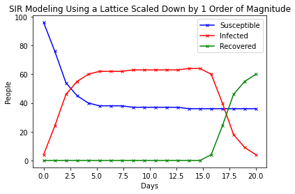

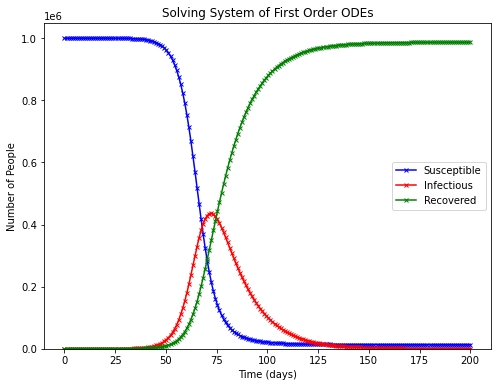

```python
print("PART A")
# I was very limited by computational power, I let my initial code run for an hour
# I scaled everything down by 10, and ran this once. I hope you see my process and know that I understand the concepts

N = 100 # population of the city #SCALED DOWN FOR COMPUTATIONAL STRAIN
Nt = 20 # 200 timesteps (days)
Nx = 10 # length of lattice in x direction # SCALED DOWN FOR COMPUTATIONAL STRAIN
Ny = 10 # length of lattice in y direction # SCALED DOWN FOR COMPUTATIONAL STRAIN
Ns = 10 # SCALED DOWN FOR COMPUTATIONAL STRAIN
D0 = Ns/2 # maximum infection distance, from problem statement
beta = 0.3 # from problem statement
gamma = 1/14 # from Georgios update sent on Slack
time = np.linspace(0,Nt,Nt)
Stot = np.zeros(Nt) # initialize array to hold total susceptible people
Itot = np.zeros(Nt) # initialize array to hold total infected people
Rtot = np.zeros(Nt) # initialize array to hold total recovered people
tries = 1 # this code made my computer fans turn on very loudly so I reduced this to 1 to limit strain
for p in range(tries): #outer for loop, at least 100 tries, doing it once because of computational strain
    lat = np.zeros((Nx,Ny)) # my lattice of all zeros
    lat[2,2] = 1 # seed 1
    lat[4,4] = 1 # seed 2
    lat[6,6] = 1 # seed 3
    lat[8,8] = 1 # seed 4
    S = np.zeros(Nt) # initialize to track susceptible people at each day
    I = np.zeros(Nt) # initialize to track infected people at each day
    R = np.zeros(Nt) # initialize to track recovered people at each day
    idays = np.zeros((Nx,Ny)) # array for days infected
    for d in range(Nt): # inner for loop for time (20 days instead of 200 days to be consistent)
        # routine to extract x and y coordinates of the infected people
        sxvalues = (np.where(lat == 0))[0] # x values of where the sus people are
        syvalues = (np.where(lat == 0))[-1] # y values of where the sus people are
        ixvalues = (np.where(lat == 1))[0] # x values of where the infected people are
        iyvalues = (np.where(lat == 1))[-1] # y values of where the infected people are
        rxvalues = (np.where(lat == -1))[0] # x values of where the recovered people are
        ryvalues = (np.where(lat == -1))[-1] # y values of where the recovered people are
        infected = np.zeros((len(ixvalues),2)) # this array will hold where the infected people are
        sus = np.zeros((len(sxvalues),2)) # this array will hold where the sus people are
        recov = np.zeros((len(rxvalues),2)) # this array will hold where the recovered people are
        for s in range(len(sxvalues)):
            sus[s]=[sxvalues[s],syvalues[s]] # puts x and y coordinates into sus array
            for i in range(len(ixvalues)):
                infected[i]=[ixvalues[i],iyvalues[i]] # puts x and y coordinates into infected array
                for r in range(len(rxvalues)):
                    recov[r]=[rxvalues[r],ryvalues[r]] # puts x and y coordinates into recov array
        S[d] = len(sxvalues) # amount of sus people at day d is length of sxvalues array
        I[d] = len(ixvalues) # amount of inf people at day d is length of ixvalues array
        R[d] = len(rxvalues) # amount of rec people at day d is length of rxvalues array

        # infecting routine
        for a in range (len(ixvalues)): # loop through # of infected people
                for b in range(int(1+D0)): # distance 0 is already infected, for x values of dotted line box
                    for c in range(int(1+D0)): # distance 0 is already infected, for y values of dotted line box
                        if np.random.rand() < beta: # if random is less than beta
                            if (ixvalues[a] + b) < Nx: # if the potentially infected person is in the x bound
                                if (iyvalues[a] + c) < Ny: # if the potentially infected person in the y bound
                                    if (lat[(ixvalues[a] + b), (iyvalues[a] + c)] == 0): # if they are susceptible
                                        lat[(ixvalues[a] + b), (iyvalues[a] + c)] = 1 # then infect that person
        # recovery routine
        for z in range(len(ixvalues)):
            idays[ixvalues[z],iyvalues[z]] +=1 # add a day for each time this loops through
            if idays[ixvalues[z],iyvalues[z]] > (1/gamma): # if they have been infected for more than 14 days
                lat[ixvalues[z],iyvalues[z]] = -1 # change to recovered, so make lattice number -1

    Stot = S + Stot # adds up number of susceptible for each try
    Itot = I + Itot # adds up number of infected for each try
    Rtot = R + Rtot # adds up number of recovered for each try

SusAverage = Stot/tries # averages susceptible total over tries
InfectedAverage = Itot/tries # averages infected total over tries
RecovAverage = Rtot/tries # averages recovered total over tries

plt.plot(time,SusAverage,'bx-',ms=4,label='Susceptible') # plots average of susceptible people as a function of time
plt.plot(time,InfectedAverage,'rx-',ms=4,label='Infected') # plots average of infected people as a function of time
plt.plot(time,RecovAverage,'gx-',ms=4,label='Recovered') # plots average of recovered people as a function of time
plt.title("SIR Modeling Using a Lattice Scaled Down by 1 Order of Magnitude")
plt.xlabel('Days')
plt.ylabel('People')
plt.legend()
plt.show()


# Solving system of first ODEs
# Total population (N) and number of days (Ndays) of epidemic duration
N = 10**6
Ndays=200

# Generating the time array:
t = np.linspace(0, Ndays, Ndays)
dt=t[1]-t[0]

# Initializing the S, I, R arrays
S=np.zeros(Ndays)
I=np.zeros(Ndays)
R=np.zeros(Ndays)

# start with one infected individual
S[0]=N
I[0]=1
R[0]=0

# Solving the system of differential equations
for n in range(Ndays-1):
    S[n+1]=S[n]+dt*(-beta*S[n]*I[n]/N)
    I[n+1]=I[n]+dt*(beta*S[n]*I[n]/N - gamma*I[n])
    R[n+1]=R[n]+dt*(gamma*I[n])

# Plotting the result (disease trajectory)
fig=plt.figure(figsize=(8,6))
plt.plot(t,S,'bx-',ms=4,label='Susceptible')
plt.plot(t,I,'rx-',ms=4,label='Infectious')
plt.plot(t,R,'gx-',ms=4,label='Recovered')

plt.xlabel('Time (days)')
plt.ylabel('Number of People')
plt.title("Solving System of First Order ODEs")
plt.ylim(0,01.05*N)
plt.legend(loc='center right')
plt.show()
```